# Assignment 1 7040

Songze Yang, u7192786

3/14/2022

```r
library(olsrr)
library(MASS)
library(Metrics)
library(leaps)
library(faraway)
```

The data containing the health insurance claim over 2 years time in the US are included in the file called ‘Data’. We split the data into training data, which include the first 300 claims, and test data, the other 308 cases. The data will be used to examine the relationship between insurance claims and all the covariates.

```r
setwd("E:/ANU Sem 2/STAT3040STAT7040 - Statistical Learning/Assignment 1")
Data <-
  read.table("Data.txt",header=TRUE,stringsAsFactors=TRUE
  )
train.data = Data[1:300,]
test.data = Data[301:length(Data$Y),]
levels(train.data$x6) <- c("low", "medium", "high")
```

## (a)

The data are summaries below. We can see that the Y (Claims) variable has large values compared to its mean as well as x2 (Procedures), x3 (Prescribed Drugs), x4 (Emergency Room Visits).

```r
summary(train.data)
```

```
##        Y                 x1             x2               x3
##  Min.   :    5.6   Min.   :40.0   Min.   : 0.000   Min.   :0.00
##  1st Qu.:  171.3   1st Qu.:55.0   1st Qu.: 1.000   1st Qu.:0.00
##  Median :  538.5   Median :60.0   Median : 3.000   Median :0.00
##  Mean   : 3028.9   Mean   :58.9   Mean   : 4.677   Mean   :0.45
##  3rd Qu.: 2061.0   3rd Qu.:64.0   3rd Qu.: 6.000   3rd Qu.:0.00
##  Max.   :45447.7   Max.   :69.0   Max.   :47.000   Max.   :7.00
##        x4               x5               x6            x7
##  Min.   : 0.000   Min.   :0.00000   low   :100   Min.   :  0.00
##  1st Qu.: 2.000   1st Qu.:0.00000   medium:150   1st Qu.: 32.25
##  Median : 3.000   Median :0.00000   high  : 50   Median :151.00
##  Mean   : 3.303   Mean   :0.04667                Mean   :161.15
##  3rd Qu.: 4.250   3rd Qu.:0.00000                3rd Qu.:282.25
##  Max.   :17.000   Max.   :1.00000                Max.   :359.00
```

We can investigate this by plotting box plot:

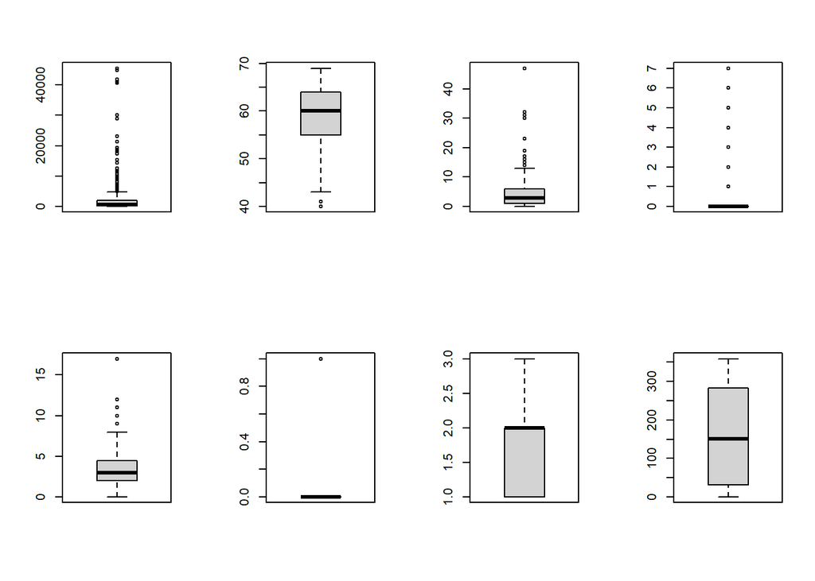

```r
par(mfrow = c(2,ncol(train.data)/2))
invisible(lapply(1:ncol(train.data), function(i)boxplot(train.data[,i])))
```

The result shows that the Y(Claims), x1(Age), x2(Procedures) and x4(Emergency Room Visits) have potential outliers in the data. The x5(Complications) have mean of approximately 0.04667, suggesting that complications are raw event. As the x5(Complications) only takes 0 and 1 value, we will not consider 1s as outliers, the reason that applied to x3(Prescribed Drugs). The other variables seem fine from the boxplots.

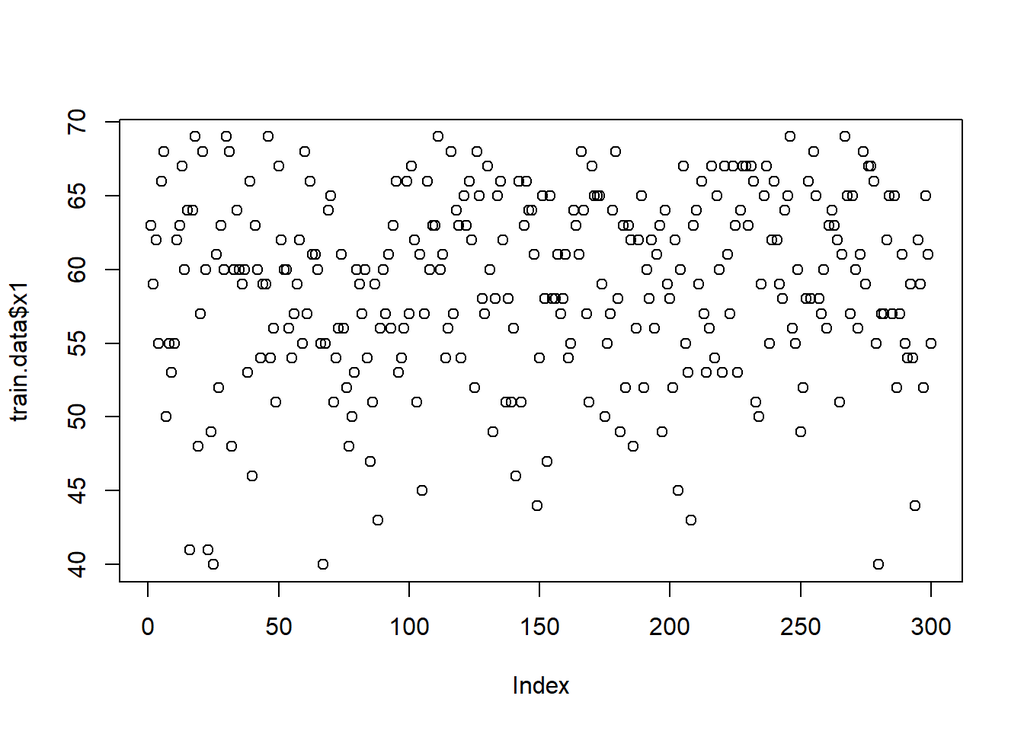

```r
plot(train.data$x1)
```

A small number of people make insurance claims at age 40, corresponding to the outliers from our box plot. However, the age data should not be excluded as we do not want left censored data. Also, many points on our scatter plot spread out in the range of 40 to 50, therefore, insurance claims made at age 40 to 50 should not be rare event.

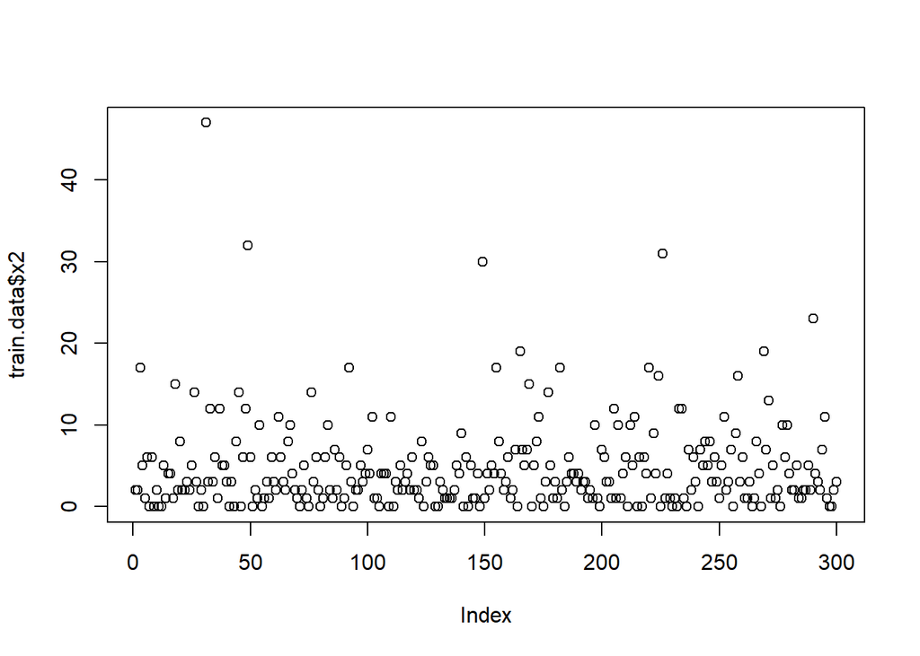

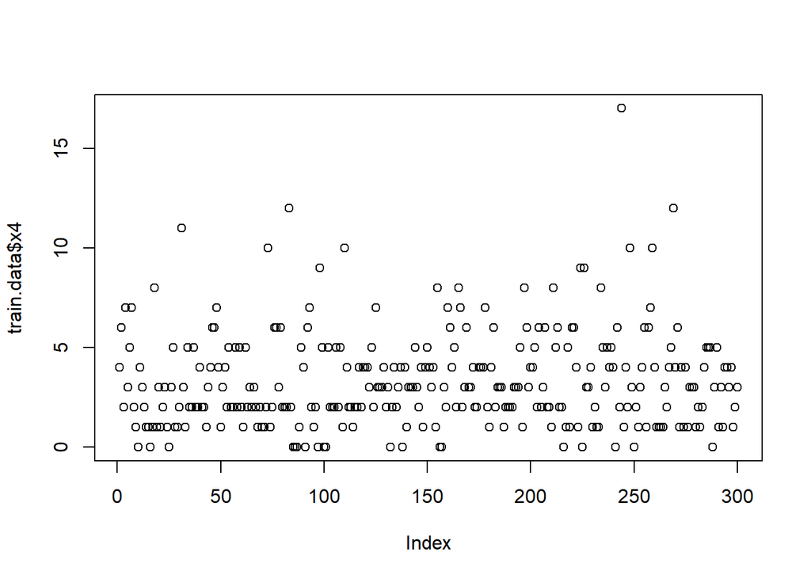

```r
plot(train.data$x2);plot(train.data$x4)
```

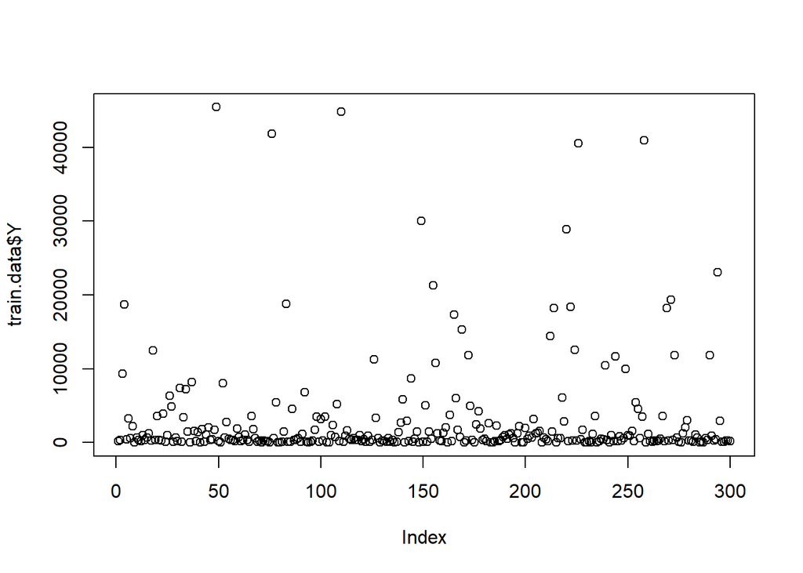

```r
plot(train.data$Y)
```

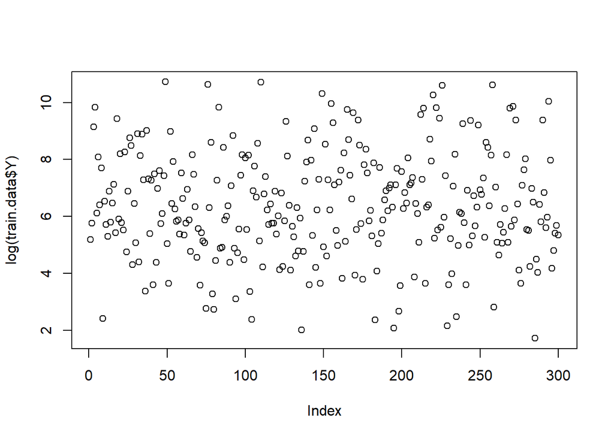

```r
plot(log(train.data$Y))
```

The Y(Claims) variable seems spread out the most. The main points center around the 0 to 10,000, while many points reach out from 10,000 to more than 40,000. However, after a log transformation, the problem of unusual points become mild.

This suggests a transformation of Y is appropriate. We further look at the transformation of features.

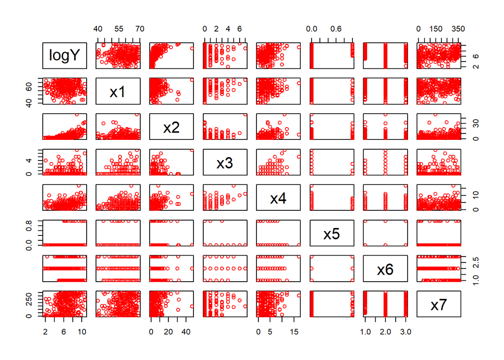

```r
train.data$logY<-log(train.data$Y)
test.data$logY<-log(test.data$Y)
pairs(train.data[,c(9,2:8)], col = "red")
```

## (b)

Fitting the linear model between Y and x3, we reach the summary table as shown below.

```r
fit<-lm(logY~x3, data = train.data)
sumary(fit)
```

```
##             Estimate Std. Error t value  Pr(>|t|)
## (Intercept) 6.254244   0.116796 53.5483 < 2.2e-16
## x3          0.289141   0.099065  2.9187  0.003783
##
## n = 300, p = 2, Residual SE = 1.86982, R-Squared = 0.03
```

Here, we conduct the hypothesis testing on the $\beta_1$.

$$H_0: \beta_1 = 0 , H_A: \beta_1 \neq 0$$

As the t-value in our linear fit is 2.9187, this suggests the linear relationship exists as the coefficient for x3 is significant at 95% confident level. We reject the null hypothesis and conclude $H_A$.

We continue to explore the ploynominal model.

```r
fit2 <- lm(logY~poly(x3 , 2), data = train.data)
fit3 <- lm(logY~poly(x3 , 3), data = train.data)
sumary(fit2); sumary(fit3)
```

```
##              Estimate Std. Error t value  Pr(>|t|)
## (Intercept)   6.38436    0.10808 59.0685 < 2.2e-16
## poly(x3, 2)1  5.45743    1.87207  2.9152  0.003825
## poly(x3, 2)2  0.99632    1.87207  0.5322  0.594985
##
## n = 300, p = 3, Residual SE = 1.87207, R-Squared = 0.03
```

```
##              Estimate Std. Error t value  Pr(>|t|)
## (Intercept)   6.38436    0.10809 59.0643 < 2.2e-16
## poly(x3, 3)1  5.45743    1.87220  2.9150  0.003829
## poly(x3, 3)2  0.99632    1.87220  0.5322  0.595012
## poly(x3, 3)3  1.83263    1.87220  0.9789  0.328448
##
## n = 300, p = 4, Residual SE = 1.87220, R-Squared = 0.03
```

F-tests are applied here, for the quadratic model:

$$H_0: \beta_1 = \beta_2 = 0 , H_A: At \ least \ one \ of \ \beta_1 \ or \ \beta_2\neq 0$$

For the cubic model:

$$H_0: \beta_1 = \beta_2 = \beta_3 = 0 , H_A: At \ least \ one \ of \ \beta_1 \ or \ \beta_2 \ or \ \beta_3\neq 0$$

For the F-tests of 4.391 and 3.246, those show that both the second and third polynomial model are significant at 5% level, advising that the higher terms improve the model residual sum of square from using the mean of Y.

```r
anova(fit,fit2)
```

```
## Analysis of Variance Table
##
## Model 1: logY ~ x3
## Model 2: logY ~ poly(x3, 2)
##   Res.Df    RSS Df Sum of Sq      F Pr(>F)
## 1    298 1041.9
## 2    297 1040.9  1   0.99265 0.2832  0.595
```

```r
anova(fit,fit3)
```

```
## Analysis of Variance Table
##
## Model 1: logY ~ x3
## Model 2: logY ~ poly(x3, 3)
##   Res.Df    RSS Df Sum of Sq      F Pr(>F)
## 1    298 1041.9
## 2    296 1037.5  2    4.3512 0.6207 0.5383
```

However, partial F-test should be conducted to see whether the polynomial improves significantly from the linear model. The test is shown below:

For quadratic model:

$$H_0: \beta_2 = 0 , H_A: \beta_2 \neq 0$$
For cubic model:

$$H_0: \beta_2 = \beta_3 = 0 , H_A: At \ least \ one \ of \ \ \beta_2 \ or \ \beta_3\neq 0$$

The higher terms improve the model very slightly, because the partial F-test for the second and third model is both not significant, namely with F-value 0.2832 and 0.6207 and p_value 0.595 and 0.5383. Hence, we conclude the linear model. The model should have flexibility as the linear model.

## (c)

We can calculate the training MSE of our model as follow:

```r
mean(fit$residuals^2)
```

```
## [1] 3.472909
```

```r
mean(fit2$residuals^2)
```

```
## [1] 3.4696
```

```r
mean(fit3$residuals^2)
```

```
## [1] 3.458405
```

The training MSE decreases, indicating the use of the higher order terms. The result is different from 1b, however, it is accorded to the fact that the $R^2$ will always increase as more parameter added.

We can calculate the test MSE using the method shown below:

```r
test.data.x <- data.frame(test.data[,2:8])
names(test.data.x) <- c("x1","x2","x3","x4","x5","x6","x7")

mse(test.data$logY,predict(fit,newdata = test.data.x))
```

```
## [1] 3.365838
```

```r
mse(test.data$logY,predict(fit2,newdata = test.data.x))
```

```
## [1] 3.387838
```

```r
mse(test.data$logY,predict(fit3,newdata = test.data.x))
```

```
## [1] 3.495392
```

The test MSE suggests the opposite. The MSE of the models increases with the term added into the model. This suggests that the linear model is the best among the three, result that is accorded to the 1b.

## (d)

First, we fit the full model as follow:

```r
full<- lm(logY~ .,data=subset(train.data, select=c(-Y)))
summary(full)
```

```
##
## Call:
## lm(formula = logY ~ ., data = subset(train.data, select = c(-Y)))
##
## Residuals:
##     Min      1Q  Median      3Q     Max
## -5.3389 -0.7978 -0.0514  0.6865  3.7112
##
## Coefficients:
##               Estimate Std. Error t value Pr(>|t|)
## (Intercept)  6.5873146  0.7423015   8.874  < 2e-16 ***
## x1          -0.0123165  0.0122409  -1.006   0.3152
## x2           0.1908628  0.0154720  12.336  < 2e-16 ***
## x3          -0.0200694  0.0845337  -0.237   0.8125
## x4           0.0757730  0.0391577   1.935   0.0540 .
## x5           0.6719013  0.3654452   1.839   0.0670 .
## x6medium    -1.2365434  0.2234377  -5.534 6.98e-08 ***
## x6high      -0.6088829  0.2361163  -2.579   0.0104 *
## x7           0.0004779  0.0008307   0.575   0.5656
## ---
## Signif. codes:  0 '***' 0.001 '**' 0.01 '*' 0.05 '.' 0.1 ' ' 1
##
## Residual standard error: 1.29 on 291 degrees of freedom
## Multiple R-squared:  0.548,  Adjusted R-squared:  0.5355
## F-statistic: 44.09 on 8 and 291 DF,  p-value: < 2.2e-16
```

The full model reveals potentially x1, x3 and x7 may be insignificant to the model individually. To whether the variables are significant in the presence of all other model, we can use a backward selection based on partial F test.

```r
fin<-ols_step_backward_p(lm(train.data$logY~.,data = subset(train.data, select = c(-Y))),prem = 0.05)
fin
```

```
##
##
##                            Elimination Summary
## -------------------------------------------------------------------------
##         Variable                  Adj.
## Step    Removed     R-Square    R-Square     C(p)        AIC        RMSE
## -------------------------------------------------------------------------
##    1    x3            0.5479       0.537    5.0564    1013.1832    1.2882
##    2    x7            0.5474      0.5381    3.3813    1011.5179    1.2867
##    3    x1             0.546      0.5383    2.2526    1010.4137    1.2864
## -------------------------------------------------------------------------
```

The result suggests that we can drop x1, x3 and x7 from the full model as we analysed. The hypothesis tested by partial F-test is shown as:

$$H_0: \beta_p = 0 , H_A: \beta_p \neq 0 \ , \ in\ the \ presence \ of \ all \ other \ variable$$

in the backward selection, the x3 is most insignificant in the presence of all other variables, followed by the x7 and x1. The significant level is 0.05, which is consistent with the question.

```r
fin$model
```

```
##
## Call:
## lm(formula = paste(response, "~", paste(preds, collapse = " + ")),
##     data = l)
##
## Coefficients:
## (Intercept)           x2           x4           x5     x6medium       x6high
##     5.97921      0.19282      0.07073      0.71571     -1.31537     -0.63572
```

Our final model fits as follow:

$$log(Y) = 5.97921 + 0.19282*x_2+ 0.07073*x_4 + 0.71571*x_5 -1.31537*x_6medium -0.63572* x_6high$$

## (e)

We can fit each model in the backward selection process and see whether the process produces a better model.

```r
reduced1<-update(full, ~. -x3)
reduced2<-update(full, ~. -x3-x7)
reduced3<-update(full, ~. -x3-x7-x1)
```

Now, we try the MSE to select the final model and compare it with the model selection process before. The MSE for training data is as followed:

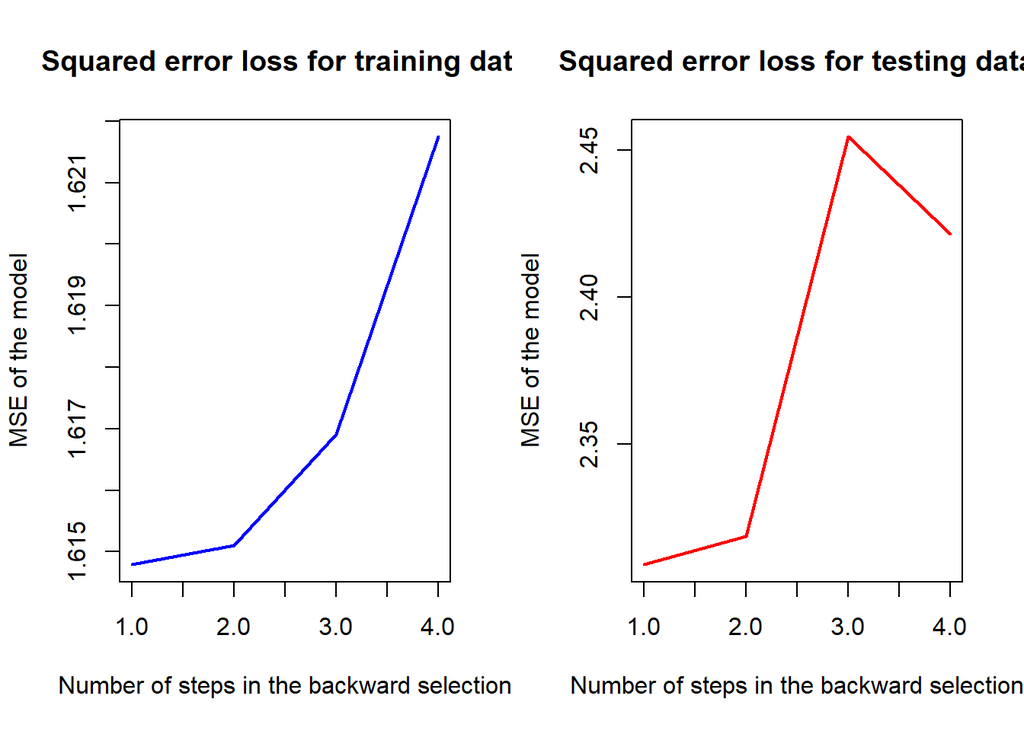

```r
elist<-c(1:4)
elist[1]<-mean(full$residuals^2)
elist[2]<-mean(reduced1$residuals^2)
elist[3]<-mean(reduced2$residuals^2)
elist[4]<-mean(reduced3$residuals^2)

elite<-c(1:4)
elite[1]<-mse(test.data$logY,predict(full,test.data.x))
elite[2]<-mse(test.data$logY,predict(reduced1,test.data.x))
elite[3]<-mse(test.data$logY,predict(reduced2,test.data.x))
elite[4]<-mse(test.data$logY,predict(reduced3,test.data.x))
par(mfrow = c(1,2))
plot(1:4,elist, lty = 1, type = "l",lwd = 2, col = "blue",
     xlab = "Number of steps in the backward selection",
     ylab = "MSE of the model",
     main = "Squared error loss for training data")
plot(1:4,elite,lty = 1, type = "l",lwd = "2",col = "red",
     xlab = "Number of steps in the backward selection",
     ylab = "MSE of the model",
     main = "Squared error loss for testing data")
```

From the training MSE, we can see that the backward selection process gives us slightly higher MSE models. If we select our model based solely on the training square error loss, we should stick with the full model.

The testing MSE during the backward selection process appears to incline at first and decline in the final model. However, the final model selected has greater MSE compared to the full model. In conclusion, we should use the full model based on MSE. The training and testing MSE both suggests that we should use the full model.

## (f)

The interaction model of x6(Comorbidities) and other variables can be fitted as shown:

```r
intfit<-lm(logY~. +x1:x6 + x2:x6 + x3:x6 + x4:x6 + x5:x6 + x7:x6, data=subset(train.data, select=c(-Y)))
intfin<-ols_step_backward_p(intfit,prem = 0.05)
summary(intfit)
```

```
##
## Call:
## lm(formula = logY ~ . + x1:x6 + x2:x6 + x3:x6 + x4:x6 + x5:x6 +
##     x7:x6, data = subset(train.data, select = c(-Y)))
##
## Residuals:
##     Min      1Q  Median      3Q     Max
## -5.8720 -0.7288  0.0149  0.6881  3.8248
##
## Coefficients:
##               Estimate Std. Error t value Pr(>|t|)
## (Intercept)  5.3644209  1.4227410   3.770 0.000199 ***
## x1           0.0079205  0.0239816   0.330 0.741441
## x2           0.1660921  0.0280194   5.928 9.04e-09 ***
## x3          -0.2021421  0.1990745  -1.015 0.310790
## x4           0.1531298  0.0696883   2.197 0.028817 *
## x5           0.7398529  0.6858771   1.079 0.281655
## x6medium     0.0982134  1.7247428   0.057 0.954631
## x6high       1.9428876  2.2862356   0.850 0.396154
## x7           0.0002659  0.0016000   0.166 0.868113
## x1:x6medium -0.0219505  0.0291332  -0.753 0.451813
## x1:x6high   -0.0380514  0.0401636  -0.947 0.344249
## x2:x6medium  0.0355517  0.0365043   0.974 0.330948
## x2:x6high    0.0089584  0.0488293   0.183 0.854567
## x3:x6medium  0.2458522  0.2314740   1.062 0.289102
## x3:x6high    0.1408242  0.2929620   0.481 0.631113
## x4:x6medium -0.1236888  0.0915447  -1.351 0.177748
## x4:x6high   -0.0351605  0.1196121  -0.294 0.769011
## x5:x6medium -0.0340820  0.8652970  -0.039 0.968610
## x5:x6high   -0.1133365  1.0801810  -0.105 0.916512
## x6medium:x7  0.0008581  0.0019843   0.432 0.665754
## x6high:x7   -0.0017185  0.0026121  -0.658 0.511157
## ---
## Signif. codes:  0 '***' 0.001 '**' 0.01 '*' 0.05 '.' 0.1 ' ' 1
##
## Residual standard error: 1.303 on 279 degrees of freedom
## Multiple R-squared:  0.5578, Adjusted R-squared:  0.5261
## F-statistic:  17.6 on 20 and 279 DF,  p-value: < 2.2e-16
```

```r
intfin
```

```
##
##
##                            Elimination Summary
## --------------------------------------------------------------------------
##         Variable                  Adj.
## Step    Removed     R-Square    R-Square     C(p)         AIC        RMSE
## --------------------------------------------------------------------------
##    1    x5:x6         0.5578      0.5295     5.0113    1028.5148    1.2986
##    2    x3            0.5578      0.5295     3.0113    1028.5148    1.2986
##    3    x3:x6         0.5558      0.5323     2.2766    1023.8723    1.2947
##    4    x1:x6         0.5545      0.5343     1.0881    1020.7396    1.2920
##    5    x7            0.5545      0.5343    -0.9119    1020.7396    1.2920
##    6    x6:x7          0.551      0.5355    -0.6989    1017.0923    1.2903
##    7    x4:x6         0.5491      0.5367    -1.4915    1014.3681    1.2886
##    8    x2:x6         0.5474      0.5381    -2.3990    1011.5179    1.2867
##    9    x1             0.546      0.5383    -3.5449    1010.4137    1.2864
## --------------------------------------------------------------------------
```

$$H_0 \ : all\ the\ interactions\ are \ 0 , H_A: at\ least\ one\ interaction\ is\ not\ 0$$

## (g)

We can fit all the model in our backward selection again and calculate the MSE.

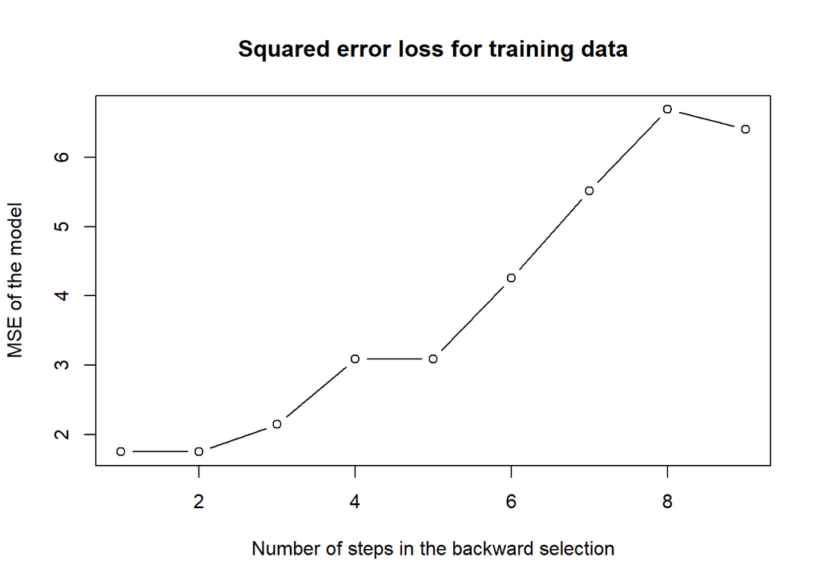

```r
inre1<-update(intfit, ~. -x5:x6)
inre2<-update(intfit, ~. -x5:x6-x3)
inre3<-update(intfit, ~. -x5:x6-x3-x3:x6)
inre4<-update(intfit, ~. -x5:x6-x3-x3:x6-x1:x6)
inre5<-update(intfit, ~. -x5:x6-x3-x3:x6-x1:x6-x7)
inre6<-update(intfit, ~. -x5:x6-x3-x3:x6-x1:x6-x7-x6:x7)
inre7<-update(intfit, ~. -x5:x6-x3-x3:x6-x1:x6-x7-x6:x7-x4:x6)
inre8<-update(intfit, ~. -x5:x6-x3-x3:x6-x1:x6-x7-x6:x7-x4:x6-x2:x6)
inre9<-update(intfit, ~. -x5:x6-x3-x3:x6-x1:x6-x7-x6:x7-x4:x6-x2:x6-x1)

MSElist<-c(1:9)
MSElist[1]<-mean(inre1$coefficients^2)
MSElist[2]<-mean(inre2$coefficients^2)
MSElist[3]<-mean(inre3$coefficients^2)
MSElist[4]<-mean(inre4$coefficients^2)
MSElist[5]<-mean(inre5$coefficients^2)
MSElist[6]<-mean(inre6$coefficients^2)
MSElist[7]<-mean(inre7$coefficients^2)
MSElist[8]<-mean(inre8$coefficients^2)
MSElist[9]<-mean(inre9$coefficients^2)
plot(1:9,MSElist, lty = 1, type = "b",
     xlab = "Number of steps in the backward selection",
     ylab = "MSE of the model",
     main = "Squared error loss for training data")
```

```r
MSElist[c(1,2)]
```

```
## [1] 1.753509 1.749599
```

```r
inre2$call
```

```
## lm(formula = logY ~ x1 + x2 + x4 + x5 + x6 + x7 + x1:x6 + x2:x6 +
##     x3:x6 + x4:x6 + x6:x7, data = subset(train.data, select = c(-Y)))
```

```r
MSElist1<-c(1:9)

yhatp1<-predict(inre1, newdata = test.data.x)
MSElist1[1]<-mean((test.data$logY - yhatp1)^2)


yhatp2<-predict(inre2, newdata = test.data.x)
MSElist1[2]<-mean((test.data$logY - yhatp2)^2)

yhatp3<-predict(inre3, newdata = test.data.x)
MSElist1[3]<-mean((test.data$logY - yhatp3)^2)

yhatp4<-predict(inre4, newdata = test.data.x)
MSElist1[4]<-mean((test.data$logY - yhatp4)^2)

yhatp5<-predict(inre5, newdata = test.data.x)
MSElist1[5]<-mean((test.data$logY - yhatp5)^2)

yhatp6<-predict(inre6, newdata = test.data.x)
MSElist1[6]<-mean((test.data$logY - yhatp6)^2)

yhatp7<-predict(inre7, newdata = test.data.x)
MSElist1[7]<-mean((test.data$logY - yhatp7)^2)

yhatp8<-predict(inre8, newdata = test.data.x)
MSElist1[8]<-mean((test.data$logY - yhatp8)^2)

yhatp9<-predict(inre9, newdata = test.data.x)
MSElist1[9]<-mean((test.data$logY - yhatp9)^2)
mse(test.data$logY,predict(inre9, newdata = test.data.x))
```

```
## [1] 2.421596
```

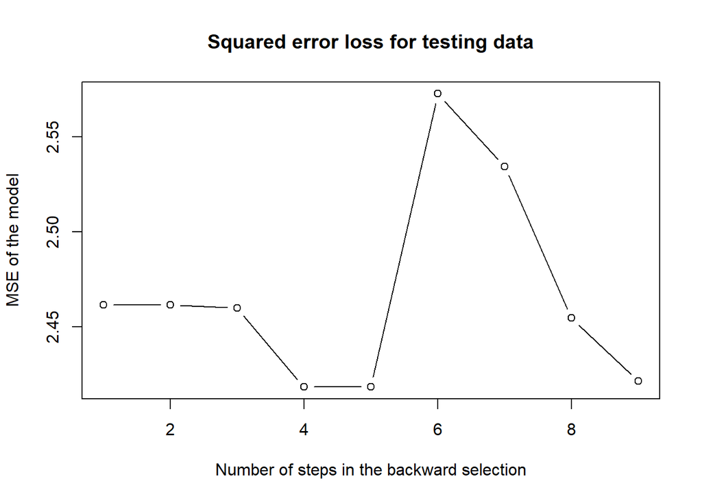

```r
plot(1:9,MSElist1, lty = 1, type = "b",
     xlab = "Number of steps in the backward selection",
     ylab = "MSE of the model",
     main = "Squared error loss for testing data")
```

```r
MSElist1[c(4,5,9)]
```

```
## [1] 2.418497 2.418497 2.421596
```

The squared error lost for test data fluctuates through the backward selection process. The model first decreases in MSE until step 5, then undergos a upward and then downward trend, eventually settles at the step 9. The minimum MSE of the models achieves at step 5, suggesting that the best model based on testing MSE should be model 5 but not the final model for the backward selection approach.

The model we use is:

```r
inre5$call
```

```
## lm(formula = logY ~ x1 + x2 + x4 + x5 + x6 + x2:x6 + x4:x6 +
##     x6:x7, data = subset(train.data, select = c(-Y)))
```

## (h)

```r
train.data$srx2<-sqrt(train.data$x2)
train.data$srx3<-sqrt(train.data$x3)
train.data$srx4<-sqrt(train.data$x4)

test.data$srx2<-sqrt(test.data$x2)
test.data$srx3<-sqrt(test.data$x3)
test.data$srx4<-sqrt(test.data$x4)
```

```r
modelboth_p<-ols_step_both_p(lm(logY~., data=subset(train.data, select=c(-Y))),pent = 0.05,prem = 0.1)
nullmodel<-lm(logY~1, data = train.data)
modelboth_aic<-stepAIC(nullmodel, direction = "both", scope = list(lower = ~1, upper = ~x1+x2+x3+x4+x5+x6+x7+srx2+srx3+srx4))
n<-dim(train.data)[1]
modelboth_bic<-stepAIC(nullmodel, direction = "both", k=log(n),scope = list(lower = ~1, upper = ~x1+x2+x3+x4+x5+x6+x7+srx2+srx3+srx4))
```

```r
test.data.x <- data.frame(test.data[,c(2:8,10:12)])
names(test.data.x) <- c("x1","x2","x3","x4","x5","x6","x7","srx2","srx3","srx4")

modelaic<-lm(logY ~ srx2 + x6 + x4 + x5, data = train.data)
mse(test.data$logY,predict(modelaic, newdata = test.data.x))
```

```
## [1] 2.087747
```

```r
modelbic<-lm(logY ~ srx2 + x6, data = train.data)
yhath1<-predict(modelbic, newdata = test.data.x)
mse(test.data$logY,yhath1)
```

```
## [1] 2.104538
```

As we can see the results, the test data suggest the AIC model is a better model providing a lower testing MSE.

## (i)

Second look at the model:

```r
modelaic$call
```

```
## lm(formula = logY ~ srx2 + x6 + x4 + x5, data = train.data)
```

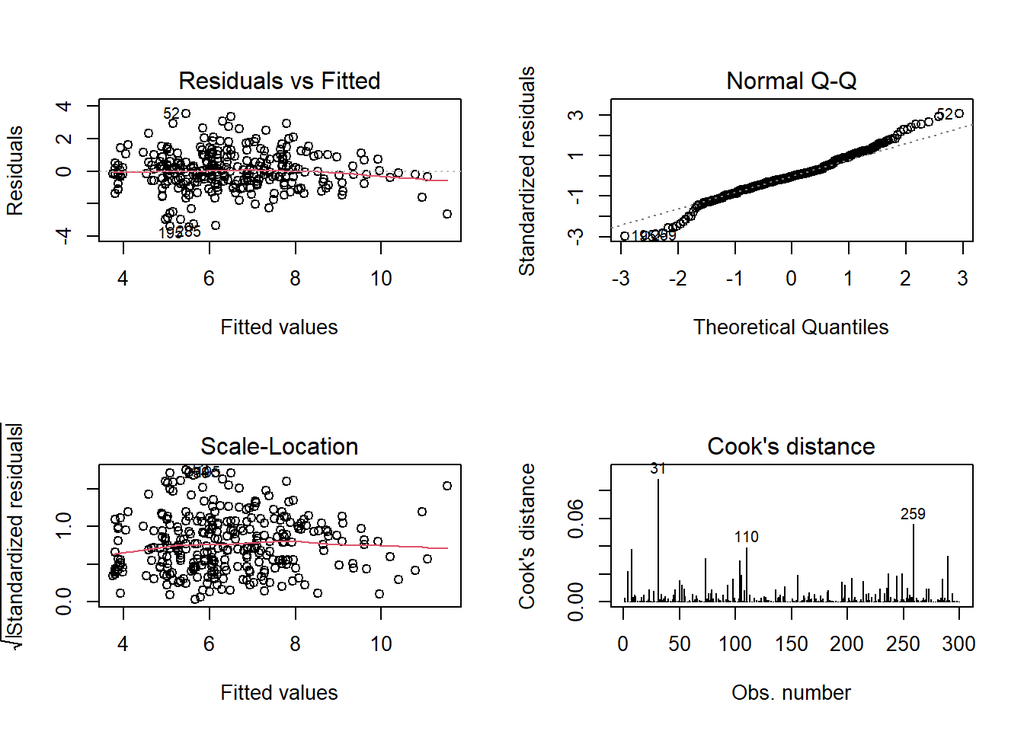

```r
par(mfrow = c(2,2))
plot(modelaic, which = c(1,2,3,4))
```

The model assumption is quite accorded. The points are equally spaced in the residual plot. Three high leverage points appear as point 31,110 and 259. We consider to remove the highest two influential points and to refit the model again.

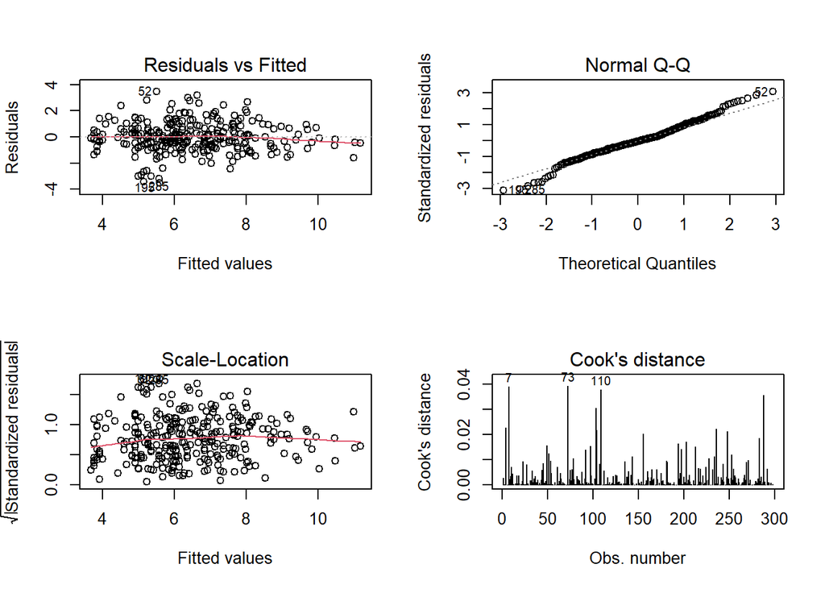

```r
modelaicad<-lm(logY ~ srx2 + x6 + x4 + x5, data = train.data[c(-31,-259),])
par(mfrow = c(2,2))
plot(modelaicad,which = c(1,2,3,4))
```

New influential points appear but as they are all similar value, which has much smaller cook’distance than before. We will consider to keep them in our model.

To check if the variables are correlated, the variance inflation factor is shown below. There is no obvious correlation between our predictor.

```r
vif(modelaic)
```

```
##     srx2 x6medium   x6high       x4       x5
## 1.237665 1.286795 1.278055 1.186025 1.035984
```

The model can be expressed as:

$$log(Y) = 4.949892+ 1.041477*sqrt(x_2)-1.209650*x_6medium -0.488577* x_6high + 0.060145*x_4 + 0.717215*x_5$$

```r
confint(modelaicad)
```

```
##                   2.5 %      97.5 %
## (Intercept)  4.48683937  5.17280389
## srx2         0.93888682  1.18800244
## x6medium    -1.44824439 -0.86104979
## x6high      -0.87572749 -0.09455589
## x4           0.02455508  0.14257240
## x5           0.01946922  1.26481725
```

As we can see from confident interval table, the top 4 predictors have narrow confident intervals and only x5 have large confident interval compared to others, but not too large as well. The coefficient in our model is reasonably checked.

The coefficient in our model can be interpreted as below:

Holding all the variables in our model constant, the procedure increases one unit, the claims payment increase the e to the power of square of 1.041477 times.